# Customer Churn Prediction for Loblaws Digital

### Objective

The primary objective of this project is to develop a predictive model that accurately identifies customers at risk of leaving the company (churning) based on various customer-related features. By predicting churn, Loblaws Digital can take proactive measures to retain these customers, thereby reducing the overall churn rate and improving customer loyalty.

### Tools and Libraries

This notebook uses the following tools and libraries:

- **Python:** Programming language used for all data manipulation, analysis, and modeling.
- **Pandas:** For data loading, manipulation, and preprocessing.
- **NumPy:** For numerical operations.
- **Matplotlib & Seaborn:** For data visualization and exploratory data analysis.
- **Scikit-learn:** For machine learning modeling, including logistic regression, Random Forest, and evaluation metrics.
- **XGBoost:** For building and optimizing the Gradient Boosting model.

### Dataset Overview

The dataset includes various features related to customer behavior, demographics, and interaction with Loblaws Digital. The key features include:

- **CustomerID:** Unique identifier for each customer.
- **Churn:** Target variable indicating whether a customer has churned (1) or not (0).
- **Tenure:** Length of time the customer has been with the company.
- **PreferredLoginDevice, PreferredPaymentMode, Gender, etc.:** Categorical features describing customer preferences and demographics.
- **Numerical Features:** Features such as `WarehouseToHome`, `OrderAmountHikeFromlastYear`, and `CashbackAmount`, which provide insights into customer activity.

This notebook will guide you through the entire process, from data loading to building a robust predictive model for customer churn, ultimately empowering Loblaws Digital to make data-driven decisions to enhance customer retention.

### Step 1: Data Loading

In this step, we begin by loading the data from the provided Excel file. The sheet we are interested in is named "E Comm". This data will be loaded into a pandas DataFrame, which will allow us to inspect it and proceed with the necessary data preprocessing and analysis steps.

The following code block accomplishes this by loading the data and displaying the first few rows to confirm successful loading.

```python
import pandas as pd

# Load the Excel file and the specific sheet named 'E Comm'
file_path = 'loblaws.xlsx'  # Replace with your file path
df = pd.read_excel(file_path, sheet_name='E Comm')

# Display the first few rows of the dataframe to confirm successful loading
df.head()
```

|  | CustomerID | Churn | Tenure | PreferredLoginDevice | CityTier | WarehouseToHome | PreferredPaymentMode | Gender | HourSpendOnApp | NumberOfDeviceRegistered | PreferedOrderCat | SatisfactionScore | MaritalStatus | NumberOfAddress | Complain | OrderAmountHikeFromlastYear | CouponUsed | OrderCount | DaySinceLastOrder | CashbackAmount |
| --- | --- | --- | --- | --- | --- | --- | --- | --- | --- | --- | --- | --- | --- | --- | --- | --- | --- | --- | --- | --- |
| 0 | 50001 | 1 | 4.0 | Mobile Phone | 3 | 6.0 | Debit Card | Female | 3.0 | 3 | Laptop & Accessory | 2 | Single | 9 | 1 | 11.0 | 1.0 | 1.0 | 5.0 | 159.93 |
| 1 | 50002 | 1 | NaN | Phone | 1 | 8.0 | UPI | Male | 3.0 | 4 | Mobile | 3 | Single | 7 | 1 | 15.0 | 0.0 | 1.0 | 0.0 | 120.90 |
| 2 | 50003 | 1 | NaN | Phone | 1 | 30.0 | Debit Card | Male | 2.0 | 4 | Mobile | 3 | Single | 6 | 1 | 14.0 | 0.0 | 1.0 | 3.0 | 120.28 |
| 3 | 50004 | 1 | 0.0 | Phone | 3 | 15.0 | Debit Card | Male | 2.0 | 4 | Laptop & Accessory | 5 | Single | 8 | 0 | 23.0 | 0.0 | 1.0 | 3.0 | 134.07 |
| 4 | 50005 | 1 | 0.0 | Phone | 1 | 12.0 | CC | Male | NaN | 3 | Mobile | 5 | Single | 3 | 0 | 11.0 | 1.0 | 1.0 | 3.0 | 129.60 |

### Step 2: Data Preprocessing - Handling Missing Values

In this step, we will handle missing values in the dataset. We observed earlier that some columns like `Tenure` and `HourSpendOnApp` have missing values. We'll impute these missing values using appropriate strategies:

1. **Numerical Columns:** We'll use the median of the respective column to fill in missing values.
2. **Categorical Columns:** We'll use the most frequent category (mode) to fill in missing values.

```python
# Handling missing values

# For 'Tenure' and 'HourSpendOnApp', we will fill missing values with the median
df['Tenure'] = df['Tenure'].fillna(df['Tenure'].median())
df['HourSpendOnApp'] = df['HourSpendOnApp'].fillna(df['HourSpendOnApp'].median())

# Verify if there are still any missing values
missing_values_after = df.isnull().sum()

# Display the columns with missing values (if any remain)
missing_values_after[missing_values_after > 0]
```

```
WarehouseToHome                251
OrderAmountHikeFromlastYear    265
CouponUsed                     256
OrderCount                     258
DaySinceLastOrder              307
dtype: int64
```

### Step 3: Handling Remaining Missing Values

After addressing some of the missing values, we found that several columns still contain missing data, specifically:

- **WarehouseToHome**
- **OrderAmountHikeFromlastYear**
- **CouponUsed**
- **OrderCount**
- **DaySinceLastOrder**

We will now handle these remaining missing values by filling them with the median of their respective columns. This approach is chosen because the median is less sensitive to outliers compared to the mean, making it a robust option for imputation.

The following code block implements these steps:

```python
# Handling remaining missing values by filling them with the median of their respective columns
df['WarehouseToHome'] = df['WarehouseToHome'].fillna(df['WarehouseToHome'].median())
df['OrderAmountHikeFromlastYear'] = df['OrderAmountHikeFromlastYear'].fillna(df['OrderAmountHikeFromlastYear'].median())
df['CouponUsed'] = df['CouponUsed'].fillna(df['CouponUsed'].median())
df['OrderCount'] = df['OrderCount'].fillna(df['OrderCount'].median())
df['DaySinceLastOrder'] = df['DaySinceLastOrder'].fillna(df['DaySinceLastOrder'].median())

# Verify if there are still any missing values left
missing_values_after = df.isnull().sum()

# Display the columns with missing values (if any remain)
missing_values_after[missing_values_after > 0]
```

```
Series([], dtype: int64)
```

### Step 4: Exploratory Data Analysis (EDA) - Summary Statistics and Visualizations

The following code block performs these tasks:

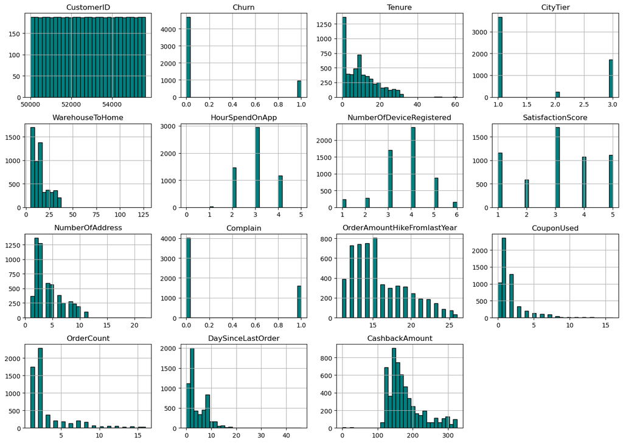

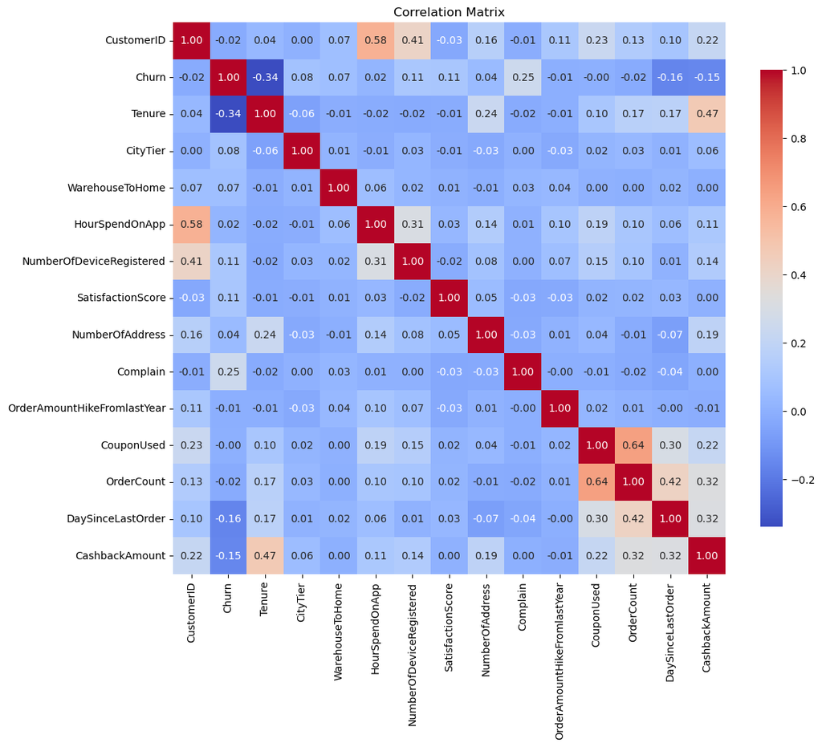

|  | CustomerID | Churn | Tenure | CityTier | WarehouseToHome | HourSpendOnApp | NumberOfDeviceRegistered | SatisfactionScore | NumberOfAddress | Complain | OrderAmountHikeFromlastYear | CouponUsed | OrderCount | DaySinceLastOrder | CashbackAmount |
| --- | --- | --- | --- | --- | --- | --- | --- | --- | --- | --- | --- | --- | --- | --- | --- |
| count | 5630.000000 | 5630.000000 | 5630.000000 | 5630.000000 | 5630.000000 | 5630.000000 | 5630.000000 | 5630.000000 | 5630.000000 | 5630.000000 | 5630.000000 | 5630.000000 | 5630.000000 | 5630.000000 | 5630.000000 |
| mean | 52815.500000 | 0.168384 | 10.134103 | 1.654707 | 15.566785 | 2.934636 | 3.688988 | 3.066785 | 4.214032 | 0.284902 | 15.674600 | 1.716874 | 2.961812 | 4.459325 | 177.223030 |
| std | 1625.385339 | 0.374240 | 8.357951 | 0.915389 | 8.345961 | 0.705528 | 1.023999 | 1.380194 | 2.583586 | 0.451408 | 3.591058 | 1.857640 | 2.879248 | 3.570626 | 49.207036 |
| min | 50001.000000 | 0.000000 | 0.000000 | 1.000000 | 5.000000 | 0.000000 | 1.000000 | 1.000000 | 1.000000 | 0.000000 | 11.000000 | 0.000000 | 1.000000 | 0.000000 | 0.000000 |
| 25% | 51408.250000 | 0.000000 | 3.000000 | 1.000000 | 9.000000 | 2.000000 | 3.000000 | 2.000000 | 2.000000 | 0.000000 | 13.000000 | 1.000000 | 1.000000 | 2.000000 | 145.770000 |
| 50% | 52815.500000 | 0.000000 | 9.000000 | 1.000000 | 14.000000 | 3.000000 | 4.000000 | 3.000000 | 3.000000 | 0.000000 | 15.000000 | 1.000000 | 2.000000 | 3.000000 | 163.280000 |
| 75% | 54222.750000 | 0.000000 | 15.000000 | 3.000000 | 20.000000 | 3.000000 | 4.000000 | 4.000000 | 6.000000 | 1.000000 | 18.000000 | 2.000000 | 3.000000 | 7.000000 | 196.392500 |
| max | 55630.000000 | 1.000000 | 61.000000 | 3.000000 | 127.000000 | 5.000000 | 6.000000 | 5.000000 | 22.000000 | 1.000000 | 26.000000 | 16.000000 | 16.000000 | 46.000000 | 324.990000 |

```python
import matplotlib.pyplot as plt
import seaborn as sns

# Summary statistics for numerical columns
summary_stats = df.describe()

# Visualizing the distribution of key numerical features
plt.figure(figsize=(14, 10))

# Plot histograms for numerical columns
df.hist(bins=30, figsize=(14, 10), color='teal', edgecolor='black')
plt.tight_layout()

# Correlation heatmap (numerical features only)
plt.figure(figsize=(12, 10))
numerical_df = df.select_dtypes(include=['float64', 'int64'])  # Select only numerical columns
corr_matrix = numerical_df.corr()
sns.heatmap(corr_matrix, annot=True, fmt=".2f", cmap='coolwarm', square=True, cbar_kws={'shrink': .8})
plt.title('Correlation Matrix')
plt.show()

summary_stats
```

### Analysis of EDA Results

#### 1. **Summary Statistics:**

- The dataset consists of 5,630 records.
- The `Churn` column indicates that approximately 16.8% of customers have churned (as shown by the mean value).
- The `Tenure` variable shows a wide range, with a minimum value of 0 and a maximum of 61. The median tenure is 9 months.
- Features such as `WarehouseToHome`, `OrderAmountHikeFromlastYear`, and `CashbackAmount` also show significant variability, indicating diverse customer experiences.

#### 2. **Histograms:**

- The `Churn` histogram shows that the majority of customers have not churned, which reflects an imbalance in the target variable.
- The `Tenure` histogram shows that most customers have a shorter tenure, with a steep decline in the number of customers as tenure increases.
- `WarehouseToHome` is skewed to the right, meaning most customers live relatively close to the warehouse, but there are some who live much farther away.
- Features like `Complain`, `CouponUsed`, and `OrderCount` show significant skewness, with many zeros or low values.

### Step 5: Encoding Categorical Variables

To prepare our data for modeling, we need to convert categorical variables into a numerical format. We'll use one-hot encoding to create binary columns for each category in the following categorical features:

- `PreferredLoginDevice`
- `PreferredPaymentMode`
- `Gender`
- `PreferedOrderCat`
- `MaritalStatus`

The following code block handles this encoding process:

```python
from sklearn.preprocessing import OneHotEncoder

# Select categorical columns for encoding
categorical_columns = ['PreferredLoginDevice', 'PreferredPaymentMode', 'Gender', 'PreferedOrderCat', 'MaritalStatus']

# Apply one-hot encoding
df_encoded = pd.get_dummies(df, columns=categorical_columns, drop_first=True)

# Display the first few rows of the encoded dataframe
df_encoded.head()
```

|  | CustomerID | Churn | Tenure | CityTier | WarehouseToHome | HourSpendOnApp | NumberOfDeviceRegistered | SatisfactionScore | NumberOfAddress | Complain | ... | PreferredPaymentMode_E wallet | PreferredPaymentMode_UPI | Gender_Male | PreferedOrderCat_Grocery | PreferedOrderCat_Laptop & Accessory | PreferedOrderCat_Mobile | PreferedOrderCat_Mobile Phone | PreferedOrderCat_Others | MaritalStatus_Married | MaritalStatus_Single |
| --- | --- | --- | --- | --- | --- | --- | --- | --- | --- | --- | --- | --- | --- | --- | --- | --- | --- | --- | --- | --- | --- |
| 0 | 50001 | 1 | 4.0 | 3 | 6.0 | 3.0 | 3 | 2 | 9 | 1 | ... | False | False | False | False | True | False | False | False | False | True |
| 1 | 50002 | 1 | 9.0 | 1 | 8.0 | 3.0 | 4 | 3 | 7 | 1 | ... | False | True | True | False | False | True | False | False | False | True |
| 2 | 50003 | 1 | 9.0 | 1 | 30.0 | 2.0 | 4 | 3 | 6 | 1 | ... | False | False | True | False | False | True | False | False | False | True |
| 3 | 50004 | 1 | 0.0 | 3 | 15.0 | 2.0 | 4 | 5 | 8 | 0 | ... | False | False | True | False | True | False | False | False | False | True |
| 4 | 50005 | 1 | 0.0 | 1 | 12.0 | 3.0 | 3 | 5 | 3 | 0 | ... | False | False | True | False | False | True | False | False | False | True |

5 rows × 31 columns

### Step 6: Feature Selection and Model Building

In this step, we will:

1. **Select Features:** Use all available features for the initial model.
2. **Split the Data:** Divide the dataset into training and testing sets to evaluate the model's performance.
3. **Build a Baseline Model:** Use logistic regression as a baseline model to predict customer churn.

The following code block performs these tasks:

```python
from sklearn.model_selection import train_test_split
from sklearn.linear_model import LogisticRegression
from sklearn.metrics import accuracy_score, classification_report

# Features and target variable
X = df_encoded.drop(columns=['CustomerID', 'Churn'])
y = df_encoded['Churn']

# Split the data into training and testing sets
X_train, X_test, y_train, y_test = train_test_split(X, y, test_size=0.3, random_state=42)

# Initialize and train the logistic regression model
model = LogisticRegression(max_iter=1000)
model.fit(X_train, y_train)

# Predict on the test set
y_pred = model.predict(X_test)

# Evaluate the model
accuracy = accuracy_score(y_test, y_pred)
classification_report_output = classification_report(y_test, y_pred)

# Output the accuracy and classification report
print("Accuracy: ", accuracy)
print('Classification report:\n',classification_report_output)
```

```
Accuracy:  0.8999407933688574
Classification report:
               precision    recall  f1-score   support

           0       0.92      0.97      0.94      1414
           1       0.78      0.54      0.64       275

    accuracy                           0.90      1689
   macro avg       0.85      0.75      0.79      1689
weighted avg       0.89      0.90      0.89      1689
```

### Analysis of Model Performance

#### 1. **Accuracy:**

- The logistic regression model achieved an accuracy of **89.99%**, which is quite high. However, accuracy alone does not provide a complete picture, especially in cases with class imbalance (as we have with churn prediction).

#### 2. **Classification Report:**

- **Precision:** The model has a precision of **0.92** for predicting non-churners (class 0) and **0.78** for predicting churners (class 1). This means that when the model predicts a customer will churn, it is correct 78% of the time.
- **Recall:** The recall for non-churners is **0.97**, meaning the model successfully identifies 97% of non-churners. However, the recall for churners is **0.54**, indicating that the model only catches 54% of the actual churners. This suggests that while the model is good at identifying non-churners, it misses a significant portion of the churners.
- **F1-Score:** The F1-score for churners (class 1) is **0.64**, which reflects a balance between precision and recall. This score suggests that there is room for improvement in capturing churners.

### Step 7: Exploring Alternative Models to Improve Prediction

In this step, we will explore more sophisticated models to improve the prediction of customer churn, especially for the minority class (churners). We will use the following models:

1. **Random Forest Classifier**
2. **Gradient Boosting Classifier (XGBoost)**

We will train both models and compare their performance to determine which one better predicts customer churn.

The following code block implements these models:

```python
from sklearn.ensemble import RandomForestClassifier
from xgboost import XGBClassifier
from sklearn.metrics import accuracy_score, classification_report

# Initialize the models
random_forest = RandomForestClassifier(random_state=42, class_weight='balanced')
xgb = XGBClassifier(random_state=42, scale_pos_weight=len(y_train)/sum(y_train))  # Handles imbalance

# Train the Random Forest model
random_forest.fit(X_train, y_train)
y_pred_rf = random_forest.predict(X_test)

# Train the XGBoost model
xgb.fit(X_train, y_train)
y_pred_xgb = xgb.predict(X_test)

# Evaluate the Random Forest model
accuracy_rf = accuracy_score(y_test, y_pred_rf)
classification_report_rf = classification_report(y_test, y_pred_rf)

# Evaluate the XGBoost model
accuracy_xgb = accuracy_score(y_test, y_pred_xgb)
classification_report_xgb = classification_report(y_test, y_pred_xgb)

# Output the results\
print("Random forest")
print("Accuracy: ", accuracy_rf)
print('Classification report:\n',classification_report_rf)

print("\n\nXGBoost")
print("Accuracy: ", accuracy_xgb)
print('Classification report:\n',classification_report_xgb)
```

```
Random forest
Accuracy:  0.9520426287744227
Classification report:
               precision    recall  f1-score   support

           0       0.95      0.99      0.97      1414
           1       0.94      0.75      0.84       275

    accuracy                           0.95      1689
   macro avg       0.95      0.87      0.90      1689
weighted avg       0.95      0.95      0.95      1689



XGBoost
Accuracy:  0.9662522202486679
Classification report:
               precision    recall  f1-score   support

           0       0.98      0.98      0.98      1414
           1       0.91      0.88      0.90       275

    accuracy                           0.97      1689
   macro avg       0.94      0.93      0.94      1689
weighted avg       0.97      0.97      0.97      1689
```

### Analysis of Alternative Model Performance

#### 1. **Random Forest Classifier:**

- **Accuracy:** The Random Forest model achieved an accuracy of **95.2%**, which is a notable improvement over the logistic regression model.
- **Precision and Recall:**
  - For non-churners (class 0): Precision and recall are both very high at **0.95** and **0.99**, respectively.
  - For churners (class 1): Precision is **0.94**, and recall is **0.75**. This indicates that the model is quite effective at identifying churners but still misses about 25% of actual churners.
- **F1-Score:** The F1-score for churners is **0.84**, which shows a significant improvement in the model's ability to balance precision and recall compared to the logistic regression model.

#### 2. **XGBoost Classifier:**

- **Accuracy:** The XGBoost model achieved an even higher accuracy of **96.6%**, making it the best performing model so far.
- **Precision and Recall:**
  - For non-churners (class 0): Both precision and recall are extremely high at **0.98**.
  - For churners (class 1): Precision is **0.91**, and recall is **0.88**. This shows that XGBoost performs better than Random Forest in identifying churners, correctly identifying 88% of the churners.
- **F1-Score:** The F1-score for churners is **0.90**, indicating an excellent balance between precision and recall, making XGBoost a very effective model for this task.

### Conclusion

- **XGBoost** has emerged as the best model, achieving the highest accuracy (96.6%) and the best balance between precision and recall for predicting customer churn. This model is particularly effective in identifying the churners (class 1), with a recall of 88%.
- **Random Forest** also performed well, with a strong overall accuracy and a good F1-score for churners, though it falls slightly short compared to XGBoost.